# theCLT

Dr. J

2022-06-23

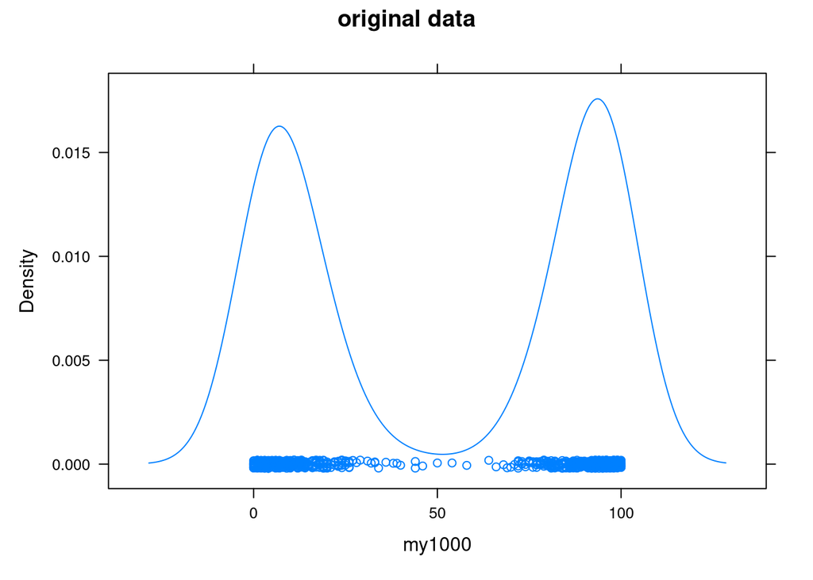

```r
KK_data <- imagpop$kkardashtemp
my1000 <- sample(KK_data, size = 1000, replace=T)
densityplot(my1000,main="original data")
```

```r
print(mean(KK_data))
```

```
## [1] 50.4003
```

```r
print(sd(KK_data))
```

```
## [1] 41.75955
```

Describe the resulting plot - is it unimodal? How many peaks does it have? Are all the peaks the same size?

Now take 2 random samples of 1000 points of the kkardashtemp variable and form 1000 points of their averages,

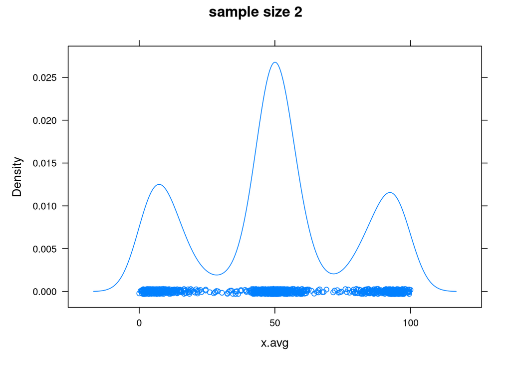

```r
numb = 2
Kdata   <- sample(KK_data, size = numb*1000, replace=T)
mdata  <-matrix(Kdata,nrow=1000,ncol=numb)
x.avg <- apply(mdata,1,mean)
densityplot(x.avg,main="sample size 2")
```

```r
print(mean(x.avg))
```

```
## [1] 49.407
```

```r
print(sd(x.avg))
```

```
## [1] 29.05107
```

Describe the resulting plot - is it unimodal? How many peaks does it have? Are all the peaks the same size?

Do this again for 4 random samples

```r
numb = 4
Kdata   <- sample(KK_data, size = numb*1000, replace=T)
mdata  <-matrix(Kdata,nrow=1000,ncol=numb)
x.avg <- apply(mdata,1,mean)
x.std<- apply(mdata,1,sd)
kkmean=mean(x.avg)
kkstd=sd(x.std)
print(mean(x.avg))
```

```
## [1] 50.06875
```

```r
print(sd(x.avg))
```

```
## [1] 21.36756
```

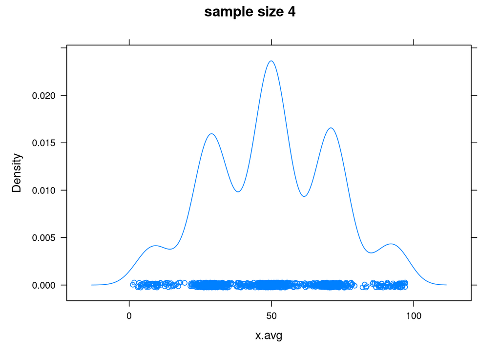

```r
densityplot(x.avg,main="sample size 4")
```